# Project 1

Katelyn Settlemyre

The purpose of this project is to be able to write various functions and to be able to use them.

# Data Processing

## First Steps

We want to write code to read in a data file, clean it up, and create two other data sets out of it. First, we will load all necessary libraries and read in our data:

```r
library(readr)
library(tibble)
library(dplyr)
library(tidyr)
library(ggplot2)

eduDat <- as_tibble(read_csv("https://www4.stat.ncsu.edu/~online/datasets/EDU01a.csv"))
```

Here, we will break down our steps of what we want to do.  
1. We only want the variables area_name, STCOU, and those ending with “D”

```r
eduDat <- select(eduDat, area_name="Area_name", STCOU, ends_with("D") )
```

2. Convert our data to long format.

```r
eduDat <- pivot_longer(eduDat, cols = 3:12, names_to = "ID", values_to = "total")
```

3. Create new columns representing the year and the measurement ID.

```r
#ID type
eduDat <- cbind(eduDat, IDType = substr(eduDat$ID, 1, 7))
#year
yr <- as.numeric(substr(eduDat$ID, 8, 9))
eduDat <- mutate(eduDat, year = if_else(substr(eduDat$IDType, 7, 7) == "1", yr+1900, yr+2000))
```

4. Create two new data sets: one with county data and one with state data. Change the class to “county” and “state,” respectively.

```r
#county data
countyIND <- grep(pattern = ", \\w\\w", eduDat$area_name)
countyDF <- as_tibble(eduDat[countyIND, ])

#state data
indn <- as.numeric(row.names(eduDat))
stateDF <- as_tibble(eduDat[!(indn %in% countyIND), ])

#add a class to county and state datasets
class(countyDF) <- c("county", class(countyDF))
class(stateDF) <- c("state", class(stateDF))
```

5. For the county level data, create a new column describing the state an entry is from.

```r
countyDF <- cbind(countyDF, state = substr(countyDF$STCOU, 1, 2))
```

6. For the state level data, create a new column describing what division a state is in.

```r
stateDF <- cbind(stateDF, division = if_else(stateDF$area_name %in% c("CONNECTICUT", "MAINE", "MASSACHUSETTS", "NEW HAMPSHIRE", "RHODE ISLAND","VERMONT"), "1",
                                        if_else(stateDF$area_name %in% c("NEW JERSEY", "NEW YORK","PENNSYLVANIA"), "2",
                                          if_else(stateDF$area_name %in% c("ILLINOIS", "INDIANA", "MICHIGAN", "OHIO", "WISCONSIN"), "3",
                                            if_else(stateDF$area_name %in% c("IOWA", "KANSAS", "MINNESOTA", "MISSOURI", "NEBRASKA", "NORTH DAKOTA", "SOUTH DAKOTA"), "4",
                                              if_else(stateDF$area_name %in% c("DELAWARE", "FLORIDA", "GEORGIA", "MARYLAND", "VIRGINIA", "NORTH CAROLINA", "SOUTH CAROLINA", "DISTRICT OF COLUMBIA", "District of Columbia", "WEST VIRGINIA"), "5",
                                                if_else(stateDF$area_name %in% c("ALABAMA", "KENTUCKY", "MISSISSIPPI", "TENNESSEE"), "6",
                                                  if_else(stateDF$area_name %in% c("ARKANSAS", "LOUISIANA", "OKLAHOMA", "TEXAS"), "7",
                                                    if_else(stateDF$area_name %in% c("ARIZONA", "COLORADO", "IDAHO", "MONTANA", "NEVADA", "NEW MEXICO", "UTAH", "WYOMING"), "8",
                                                      if_else(stateDF$area_name %in% c("ALASKA", "CALIFORNIA", "HAWAII", "OREGON", "WASHINGTON"), "9", "ERROR"))))))))))
```

This concludes our steps. However, if we want to do this again with a different data set, we’ll need to copy-paste and change things here and there. This is long and messy! Instead, we now want to write functions that do these steps for us.

## Function Junction

We’ll break down our functions much like the steps outlined previously. First, we’ll create a function to do steps 0, 1, and 2, with step 0 being where we read in our data.

```r
readSelect <- function(urlDat){
  df <- tibble::as_tibble(read.csv(urlDat))
  df <- select(df, area_name="Area_name", STCOU, ends_with("D"))
  df <- pivot_longer(df, cols = 3:12, names_to = "ID", values_to = "total")
  return(df)
}
```

Next, we want a function to do step 3.

```r
extraction <- function(df){
  df <- cbind(df, IDType = substr(df$ID, 1, 7))
  yr <- as.numeric(substr(df$ID, 8, 9))
  df <- mutate(df, year = if_else(substr(df$IDType, 7, 7) == "1", yr+1900, yr+2000))
  return(df)
}
```

Now we want a function to do step 4.

```r
regionize <- function(df){
  #county
  countyIND <- grep(pattern = ", \\w\\w", df$area_name)
  countyDF <- tibble::as_tibble(df[countyIND, ])
  class(countyDF) <- c("county", class(countyDF))

  #state
  indn <- as.numeric(row.names(df))
  stateDF <- tibble::as_tibble(df[!(indn %in% countyIND), ])
  class(stateDF) <- c("state", class(stateDF))
  return(list(county = countyDF, state = stateDF))
}
```

Finally, we want a function to do step 5 and a function to do step 6.

```r
#function for step 5
addState <- function(county){
  county <- cbind(county, state = substr(county$STCOU, 1, 2))
  return(county)
}


#function for step 6
addDiv <- function(state){
  state <- cbind(state, division = if_else(state$area_name %in% c("CONNECTICUT", "MAINE", "MASSACHUSETTS", "NEW HAMPSHIRE", "RHODE ISLAND","VERMONT"), "1",
                                     if_else(state$area_name %in% c("NEW JERSEY", "NEW YORK","PENNSYLVANIA"), "2",
                                       if_else(state$area_name %in% c("ILLINOIS", "INDIANA", "MICHIGAN", "OHIO", "WISCONSIN"), "3",
                                         if_else(state$area_name %in% c("IOWA", "KANSAS", "MINNESOTA", "MISSOURI", "NEBRASKA", "NORTH DAKOTA", "SOUTH DAKOTA"), "4",
                                           if_else(state$area_name %in% c("DELAWARE", "FLORIDA", "GEORGIA", "MARYLAND", "VIRGINIA", "NORTH CAROLINA", "SOUTH CAROLINA", "DISTRICT OF COLUMBIA", "District of Columbia", "WEST VIRGINIA"), "5",
                                             if_else(state$area_name %in% c("ALABAMA", "KENTUCKY", "MISSISSIPPI", "TENNESSEE"), "6",
                                               if_else(state$area_name %in% c("ARKANSAS", "LOUISIANA", "OKLAHOMA", "TEXAS"), "7",
                                                 if_else(state$area_name %in% c("ARIZONA", "COLORADO", "IDAHO", "MONTANA", "NEVADA", "NEW MEXICO", "UTAH", "WYOMING"), "8",
                                                   if_else(state$area_name %in% c("ALASKA", "CALIFORNIA", "HAWAII", "OREGON", "WASHINGTON"), "9", "ERROR"))))))))))
  return(state)
}
```

Thus we’ve created functions to do our steps. Now let’s create a wrapper function, putting them all together.

```r
wrapItUp <- function(url){
  df <- readSelect(url)
  df <- extraction(df)
  county <- regionize(df)$county
  state <- regionize(df)$state
  county <- addState(county)
  state <- addDiv(state)
  county <- tibble::as_tibble(county)
  state <- tibble::as_tibble(state)
  return(list(county = county, state = state))
}
```

Let’s test it and see what we get:

```r
wrapItUp("https://www4.stat.ncsu.edu/~online/datasets/EDU01a.csv")
```

```
## $county
## # A tibble: 31,450 × 7
##    area_name   STCOU ID         total IDType   year state
##    <chr>       <int> <chr>      <int> <chr>   <dbl> <chr>
##  1 Autauga, AL  1001 EDU010187D  6829 EDU0101  1987 10
##  2 Autauga, AL  1001 EDU010188D  6900 EDU0101  1988 10
##  3 Autauga, AL  1001 EDU010189D  6920 EDU0101  1989 10
##  4 Autauga, AL  1001 EDU010190D  6847 EDU0101  1990 10
##  5 Autauga, AL  1001 EDU010191D  7008 EDU0101  1991 10
##  6 Autauga, AL  1001 EDU010192D  7137 EDU0101  1992 10
##  7 Autauga, AL  1001 EDU010193D  7152 EDU0101  1993 10
##  8 Autauga, AL  1001 EDU010194D  7381 EDU0101  1994 10
##  9 Autauga, AL  1001 EDU010195D  7568 EDU0101  1995 10
## 10 Autauga, AL  1001 EDU010196D  7834 EDU0101  1996 10
## # … with 31,440 more rows
##
## $state
## # A tibble: 530 × 7
##    area_name     STCOU ID            total IDType   year division
##    <chr>         <int> <chr>         <int> <chr>   <dbl> <chr>
##  1 UNITED STATES     0 EDU010187D 40024299 EDU0101  1987 ERROR
##  2 UNITED STATES     0 EDU010188D 39967624 EDU0101  1988 ERROR
##  3 UNITED STATES     0 EDU010189D 40317775 EDU0101  1989 ERROR
##  4 UNITED STATES     0 EDU010190D 40737600 EDU0101  1990 ERROR
##  5 UNITED STATES     0 EDU010191D 41385442 EDU0101  1991 ERROR
##  6 UNITED STATES     0 EDU010192D 42088151 EDU0101  1992 ERROR
##  7 UNITED STATES     0 EDU010193D 42724710 EDU0101  1993 ERROR
##  8 UNITED STATES     0 EDU010194D 43369917 EDU0101  1994 ERROR
##  9 UNITED STATES     0 EDU010195D 43993459 EDU0101  1995 ERROR
## 10 UNITED STATES     0 EDU010196D 44715737 EDU0101  1996 ERROR
## # … with 520 more rows
```

We get exactly what we wanted: two data frames, one for state and one for county. But what if we have two data sets to read in that we need to combine?

## Combination Station

Here, we’ll create a function that takes two data sets and spits out two data frames, one for county and one for state.

```r
womboCombo <-function(county1, state1, county2, state2){
  countyCombo <- dplyr::bind_rows(county1, county2)
  countyCombo <- as_tibble(countyCombo)
  stateCombo <- dplyr::bind_rows(state1, state2)
  stateCombo <- as_tibble(stateCombo)
  return(list(cCombo = countyCombo, sCombo = stateCombo))
}
```

Let’s test it:

```r
a <- "https://www4.stat.ncsu.edu/~online/datasets/EDU01a.csv"
b <- "https://www4.stat.ncsu.edu/~online/datasets/EDU01b.csv"
dat1 <- wrapItUp(a)
dat2 <- wrapItUp(b)
womboCombo(dat1$county, dat1$state, dat2$county, dat2$state)
```

```
## $cCombo
## # A tibble: 62,900 × 7
##    area_name   STCOU ID         total IDType   year state
##    <chr>       <int> <chr>      <int> <chr>   <dbl> <chr>
##  1 Autauga, AL  1001 EDU010187D  6829 EDU0101  1987 10
##  2 Autauga, AL  1001 EDU010188D  6900 EDU0101  1988 10
##  3 Autauga, AL  1001 EDU010189D  6920 EDU0101  1989 10
##  4 Autauga, AL  1001 EDU010190D  6847 EDU0101  1990 10
##  5 Autauga, AL  1001 EDU010191D  7008 EDU0101  1991 10
##  6 Autauga, AL  1001 EDU010192D  7137 EDU0101  1992 10
##  7 Autauga, AL  1001 EDU010193D  7152 EDU0101  1993 10
##  8 Autauga, AL  1001 EDU010194D  7381 EDU0101  1994 10
##  9 Autauga, AL  1001 EDU010195D  7568 EDU0101  1995 10
## 10 Autauga, AL  1001 EDU010196D  7834 EDU0101  1996 10
## # … with 62,890 more rows
##
## $sCombo
## # A tibble: 1,060 × 7
##    area_name     STCOU ID            total IDType   year division
##    <chr>         <int> <chr>         <int> <chr>   <dbl> <chr>
##  1 UNITED STATES     0 EDU010187D 40024299 EDU0101  1987 ERROR
##  2 UNITED STATES     0 EDU010188D 39967624 EDU0101  1988 ERROR
##  3 UNITED STATES     0 EDU010189D 40317775 EDU0101  1989 ERROR
##  4 UNITED STATES     0 EDU010190D 40737600 EDU0101  1990 ERROR
##  5 UNITED STATES     0 EDU010191D 41385442 EDU0101  1991 ERROR
##  6 UNITED STATES     0 EDU010192D 42088151 EDU0101  1992 ERROR
##  7 UNITED STATES     0 EDU010193D 42724710 EDU0101  1993 ERROR
##  8 UNITED STATES     0 EDU010194D 43369917 EDU0101  1994 ERROR
##  9 UNITED STATES     0 EDU010195D 43993459 EDU0101  1995 ERROR
## 10 UNITED STATES     0 EDU010196D 44715737 EDU0101  1996 ERROR
## # … with 1,050 more rows
```

Again, we get just what we want, two large data sets, one for county and one for state.

# Plotting and Scheming

We now want to plot our data sets. For our state data, by the mean enrollment per year per division.

```r
#state plot
plot.state <- function(df){
  dat <- df %>% group_by(division, year) %>% summarise(avgEnroll = mean(total)) %>% filter(division != "ERROR")
  ggplot(dat, aes(x = year, y = avgEnroll, color = division)) + geom_line()
}
```

For our county data, we’ll do something similar, but we want to choose what state to plot.

```r
#county plot
plot.county <- function(df, st="10"){
  dat <- df %>% filter(state == st) %>% group_by(area_name, year) %>% summarise(avgEnroll = mean(total))

  ggplot(dat, aes(x = year, y = avgEnroll, color = area_name)) + geom_line()
}
```

# All Together Now

Lets use these functions now! We’ll use the processing function and then the combining function on two data sets previously used for testing. We will then use our plot functions on the combined data sets:

```r
eduA <- "https://www4.stat.ncsu.edu/~online/datasets/EDU01a.csv"
eduB <- "https://www4.stat.ncsu.edu/~online/datasets/EDU01b.csv"
eduADat <- wrapItUp(eduA)
eduBDat <- wrapItUp(eduB)

(eduDat <- womboCombo(eduADat$county, eduADat$state, eduBDat$county, eduBDat$state))
```

```
## $cCombo
## # A tibble: 62,900 × 7
##    area_name   STCOU ID         total IDType   year state
##    <chr>       <int> <chr>      <int> <chr>   <dbl> <chr>
##  1 Autauga, AL  1001 EDU010187D  6829 EDU0101  1987 10
##  2 Autauga, AL  1001 EDU010188D  6900 EDU0101  1988 10
##  3 Autauga, AL  1001 EDU010189D  6920 EDU0101  1989 10
##  4 Autauga, AL  1001 EDU010190D  6847 EDU0101  1990 10
##  5 Autauga, AL  1001 EDU010191D  7008 EDU0101  1991 10
##  6 Autauga, AL  1001 EDU010192D  7137 EDU0101  1992 10
##  7 Autauga, AL  1001 EDU010193D  7152 EDU0101  1993 10
##  8 Autauga, AL  1001 EDU010194D  7381 EDU0101  1994 10
##  9 Autauga, AL  1001 EDU010195D  7568 EDU0101  1995 10
## 10 Autauga, AL  1001 EDU010196D  7834 EDU0101  1996 10
## # … with 62,890 more rows
##
## $sCombo
## # A tibble: 1,060 × 7
##    area_name     STCOU ID            total IDType   year division
##    <chr>         <int> <chr>         <int> <chr>   <dbl> <chr>
##  1 UNITED STATES     0 EDU010187D 40024299 EDU0101  1987 ERROR
##  2 UNITED STATES     0 EDU010188D 39967624 EDU0101  1988 ERROR
##  3 UNITED STATES     0 EDU010189D 40317775 EDU0101  1989 ERROR
##  4 UNITED STATES     0 EDU010190D 40737600 EDU0101  1990 ERROR
##  5 UNITED STATES     0 EDU010191D 41385442 EDU0101  1991 ERROR
##  6 UNITED STATES     0 EDU010192D 42088151 EDU0101  1992 ERROR
##  7 UNITED STATES     0 EDU010193D 42724710 EDU0101  1993 ERROR
##  8 UNITED STATES     0 EDU010194D 43369917 EDU0101  1994 ERROR
##  9 UNITED STATES     0 EDU010195D 43993459 EDU0101  1995 ERROR
## 10 UNITED STATES     0 EDU010196D 44715737 EDU0101  1996 ERROR
## # … with 1,050 more rows
```

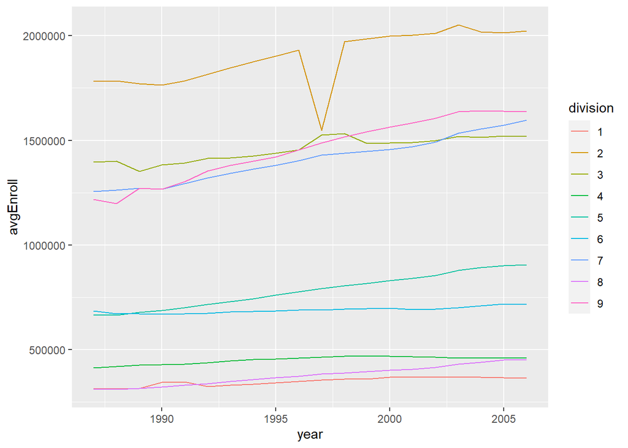

```r
plot.state(eduDat$sCombo)
```

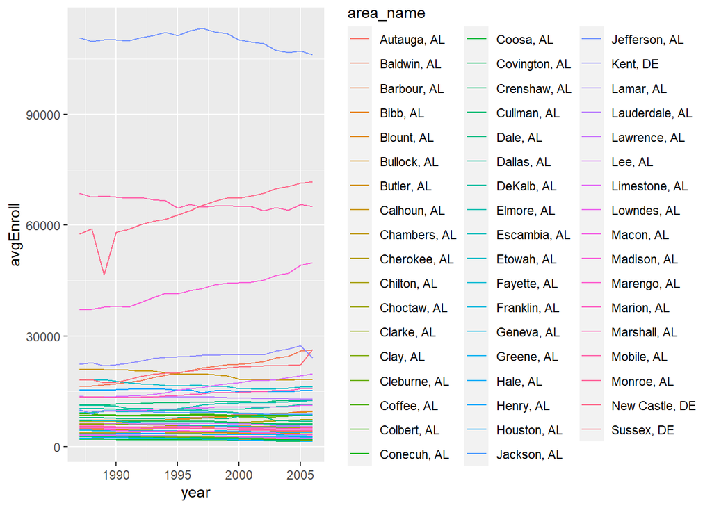

```r
plot.county(eduDat$cCombo)
```

Finally, we’ll use the functions on new data sets here:

```r
pstA <- "https://www4.stat.ncsu.edu/~online/datasets/PST01a.csv"
pstB <- "https://www4.stat.ncsu.edu/~online/datasets/PST01b.csv"
pstC <- "https://www4.stat.ncsu.edu/~online/datasets/PST01c.csv"
pstD <- "https://www4.stat.ncsu.edu/~online/datasets/PST01D.csv"

pstADat <- wrapItUp(pstA)
pstBDat <- wrapItUp(pstB)
pstCDat <- wrapItUp(pstC)
pstDDat <- wrapItUp(pstD)

pstCombo1 <- womboCombo(pstADat$county, pstADat$state, pstBDat$county, pstBDat$state)
pstCombo2 <- womboCombo(pstCDat$county, pstCDat$state, pstDDat$county, pstDDat$state)
(pstFull <- womboCombo(pstCombo1$cCombo, pstCombo1$sCombo, pstCombo2$cCombo, pstCombo2$sCombo))
```

```
## $cCombo
## # A tibble: 125,800 × 7
##    area_name   STCOU ID         total IDType   year state
##    <chr>       <int> <chr>      <int> <chr>   <dbl> <chr>
##  1 Autauga, AL  1001 PST015171D 25508 PST0151  1971 10
##  2 Autauga, AL  1001 PST015172D 27166 PST0151  1972 10
##  3 Autauga, AL  1001 PST015173D 28463 PST0151  1973 10
##  4 Autauga, AL  1001 PST015174D 29266 PST0151  1974 10
##  5 Autauga, AL  1001 PST015175D 29718 PST0151  1975 10
##  6 Autauga, AL  1001 PST015176D 29896 PST0151  1976 10
##  7 Autauga, AL  1001 PST015177D 30462 PST0151  1977 10
##  8 Autauga, AL  1001 PST015178D 30882 PST0151  1978 10
##  9 Autauga, AL  1001 PST015179D 32055 PST0151  1979 10
## 10 Autauga, AL  1001 PST025181D 31985 PST0251  1981 10
## # … with 125,790 more rows
##
## $sCombo
## # A tibble: 2,120 × 7
##    area_name     STCOU ID             total IDType   year division
##    <chr>         <int> <chr>          <int> <chr>   <dbl> <chr>
##  1 UNITED STATES     0 PST015171D 206827028 PST0151  1971 ERROR
##  2 UNITED STATES     0 PST015172D 209283904 PST0151  1972 ERROR
##  3 UNITED STATES     0 PST015173D 211357490 PST0151  1973 ERROR
##  4 UNITED STATES     0 PST015174D 213341552 PST0151  1974 ERROR
##  5 UNITED STATES     0 PST015175D 215465246 PST0151  1975 ERROR
##  6 UNITED STATES     0 PST015176D 217562728 PST0151  1976 ERROR
##  7 UNITED STATES     0 PST015177D 219759860 PST0151  1977 ERROR
##  8 UNITED STATES     0 PST015178D 222095080 PST0151  1978 ERROR
##  9 UNITED STATES     0 PST015179D 224567234 PST0151  1979 ERROR
## 10 UNITED STATES     0 PST025181D 229466391 PST0251  1981 ERROR
## # … with 2,110 more rows
```

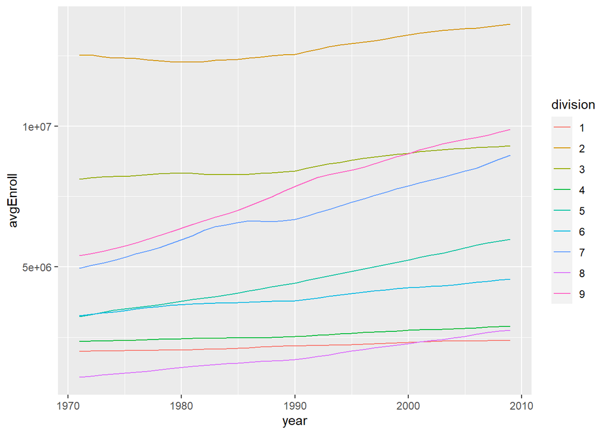

```r
plot.state(pstFull$sCombo)
```

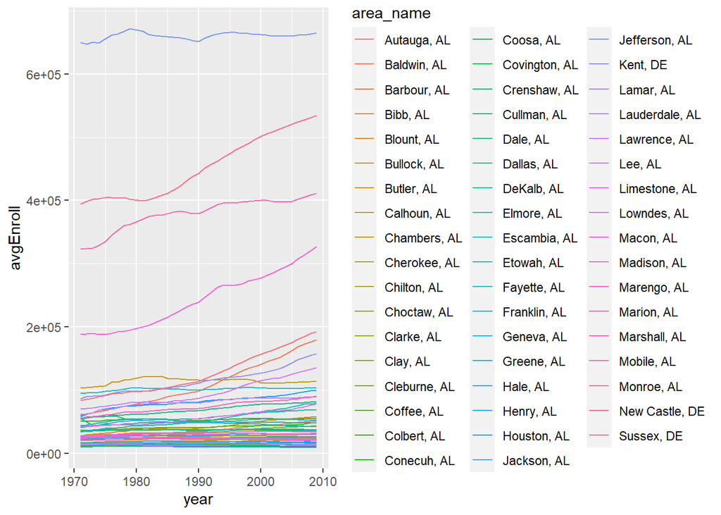

```r
plot.county(pstFull$cCombo)
```